# Bayesian ‘Poll’ Smoothing Using Internet Data

Graham Straus

2022-05-27

# Read in data

```r
dat <- read_csv("poll_smooth_stan.csv") %>%
  mutate(date = as.Date(date, format = "%d/%m/%Y")) %>%
  rename(bass = `bass voteshare`, caruso = `caruso voteshare`) %>%
  mutate(bass = ifelse(bass > 0.1, bass, 0.1))
```

# The data

I have data from four traditional polls carried out over the last month or so. Traditional polling for a mayoral race is thin so I have supplemented with data on tweets, twitter followers and google trends.

- Google trends: Google lets me limit my region of interest to Los Angeles and gives score for a given search term. I request scores for the five leading mayoral candidates in Los Angeles and say the percent in favor of Rick Caruso, for instance, on a given day is Caruso’s score over the total scores of all candidates. These scores have no inherent meaning provided by google. They are meant to be relative. I censor these to be within $[0.1, 0.9]$.
- Tweets: I grab all tweets mentioning the five leading candidates from a 15 mile radius around Los Angeles. I let the percent in favor of Rick Caruso be the number of tweets mentioning Caruso over the the total number of tweets mentioning any candidate.
- (new) Followers: I collect daily follower data and look at the number of new followers each candidate gets. The percent in favor of Caruso on a given day is then new Caruso followers over new followers for any candidate. I censor these data at 0, so even when candidates lose followers I call it 0 new followers.

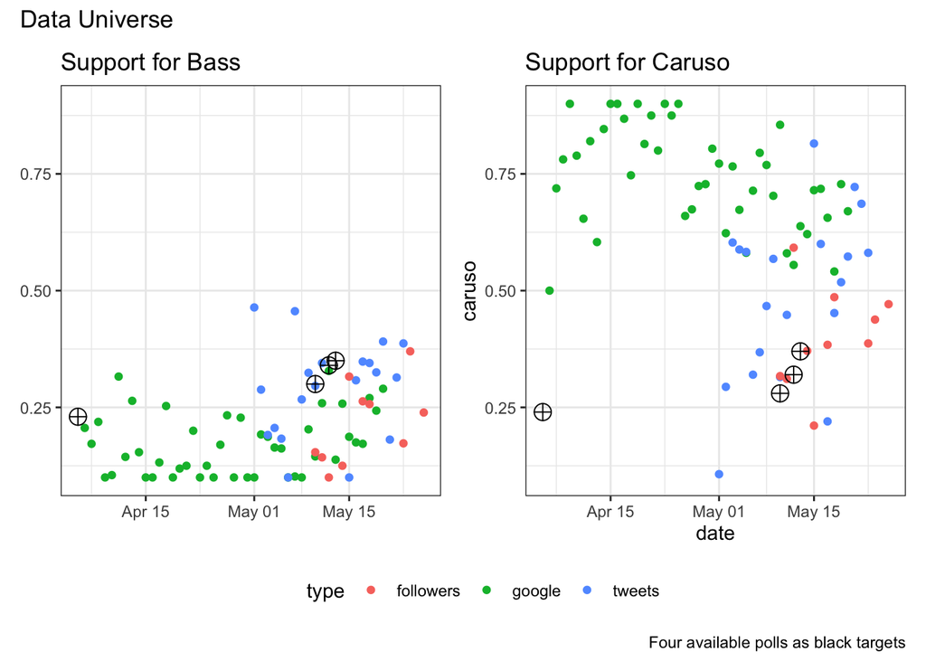

Recent polls put both leading candidates around 30% support, but Karen Bass is underperforming according to the internet data compared to the polls, whereas Rick Caruso is overperforming in the internet data compared to polls.

```stan
data {
  int n;                    // Number of rows (polls)
  int n_day;              // Number of days since first poll
  int n_house;            //4

  real voteshare[n];    //
  int day[n];       // day index
  int house[n];        // house index
  real true_outcome;
}

parameters {
  vector<lower = 0.0, upper = 1.0>[n_day] alpha_day; // alpha component of mean mu
  vector[n_house] intercept_type;
  real<lower=0.0> omega;  // s.d. of walk step

}

transformed parameters {
  vector[n] mu;
  for (i in 1:n) {
    mu[i] = alpha_day[day[i]] + intercept_type[house[i]];
  }
}

model {

  target += normal_lpdf(omega | 0, 0.2);

  target += normal_lpdf(alpha_day[64]| true_outcome, 0.0003);

  for (t in 2:n_day) {
    target += normal_lpdf(alpha_day[t] | alpha_day[t-1], omega);
  }

  for (i in 1:n) {
    target += normal_lpdf(voteshare[i] | mu[i], 0.015);
    // Lik for data
  }

}
```

```r
#prepare data
caruso_dat <- dat %>% select(-date, -bass) %>%
  rename(day = day_count,
         house = type,
         voteshare = caruso) %>%
  compose_data()
caruso_dat$n_day = 64
caruso_dat$true_outcome <- 0.4
caruso_dat


#sample
fit_caruso <- model$sample(
  data = caruso_dat,
  chains = 4,
  iter_sampling = 5000,
  thin = 2,
  parallel_chains = 4,
  refresh = 1000 # print update every 500 iters
)
```

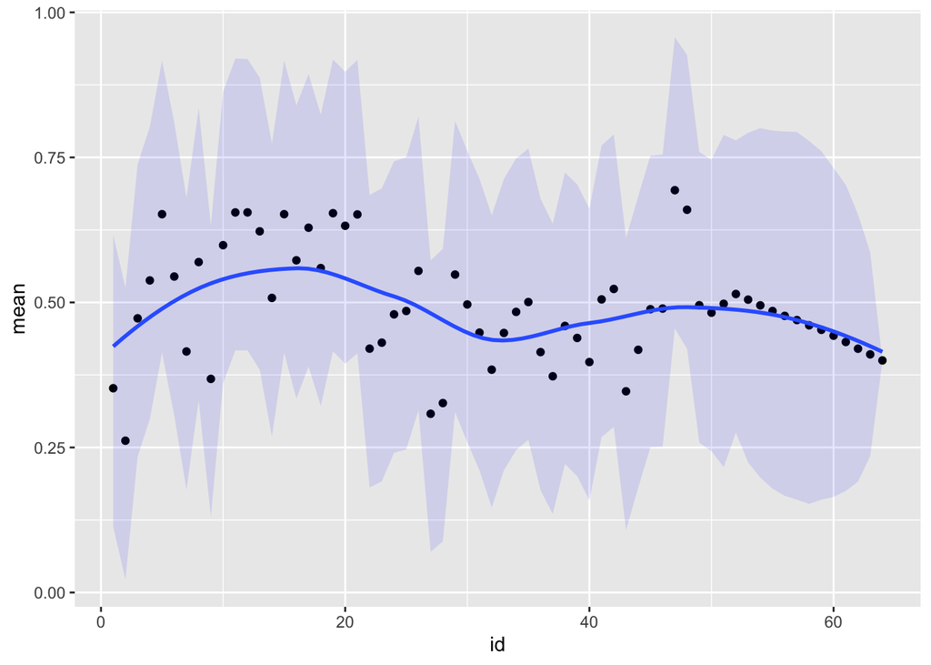

```r
fit_caruso$summary() %>%
  select(variable, mean, q5, q95) %>%
  filter(grepl("alpha", variable)) %>%
  mutate(id = 1:n()) %>%
  ggplot(., aes(x = id, y = mean, ymin = q5, ymax = q95)) +
  geom_point() +
  geom_ribbon(fill = "blue", alpha = 0.1) +
  geom_smooth(se = F)
```

```
## No divergences to plot.
```

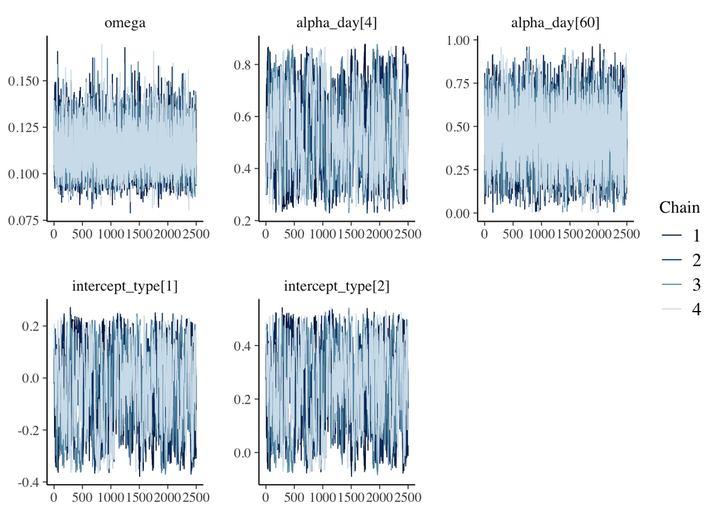

```r
#View(fit_caruso$summary())

mcmc_trace(
  fit_caruso$draws(),
  np = nuts_params(fit_caruso),
  pars = c(
    "omega",
    "alpha_day[4]",
    "alpha_day[60]",
    "intercept_type[1]",
    "intercept_type[2]"
  )
)
```

```r
bass_dat <- dat %>% select(-date, -caruso) %>%
  rename(day = day_count,
         house = type,
         voteshare = bass) %>%
  compose_data()
bass_dat$n_day = 64
#data_for_stan
#bass_dat
bass_dat$true_outcome <- 0.3


fit_bass<- model$sample(
  data = bass_dat,
  chains = 4,
  iter_sampling = 5000,
  thin = 2,
  parallel_chains = 4,
  refresh = 1000 # print update every 500 iters
)
```

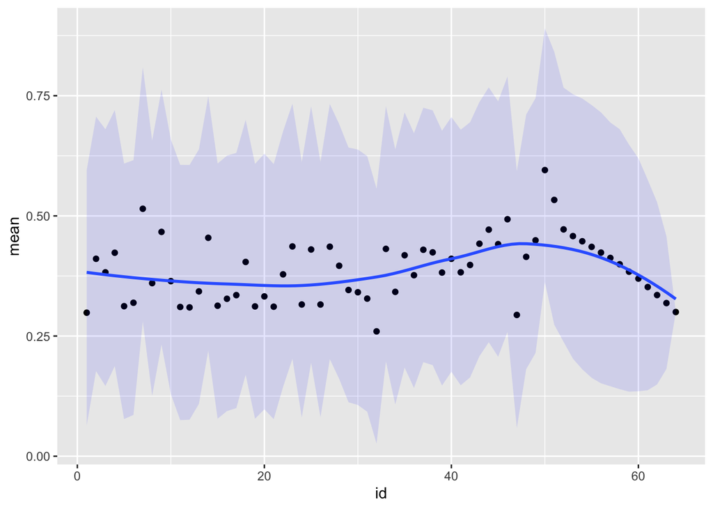

```r
fit_bass$summary() %>%
  select(variable, mean, q5, q95) %>%
  filter(grepl("alpha", variable)) %>%
  mutate(id = 1:n()) %>%
  ggplot(., aes(x = id, y = mean, ymin = q5, ymax = q95)) +
  geom_point() +
  geom_ribbon(fill = "blue", alpha = 0.1) +
  geom_smooth(se = F)
```

```
## No divergences to plot.
```

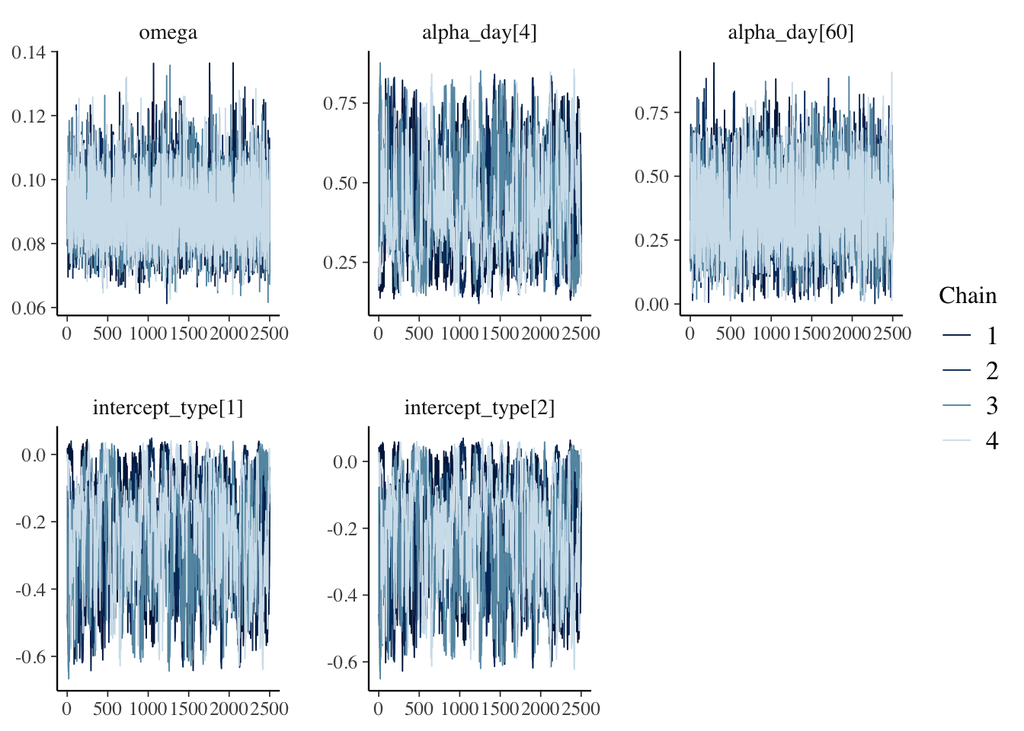

```r
#View(fit_bass$summary())
mcmc_trace(
  fit_bass$draws(),
  np = nuts_params(fit_bass),
  pars = c(
    "omega",
    "alpha_day[4]",
    "alpha_day[60]",
    "intercept_type[1]",
    "intercept_type[2]"
  )
)
```